# Introduction

## 1.Objective

YouTube nowadays is the largest video hosting website, and it has profound influences on US society in all aspects. Thus analyzing of youtube’s dataset become significant for companies to analyze the social trends and make a prediction for future strategic business plannings.

The overall objective is for investors and advertisers. We will provide business recommendations for them, like which channels have more business value, what people are concerning now, and how to target customers precisely and explore potential customers,etc.

For the strategic decisions of investors, we will help them find the category that have relatively higher business potential. We drafted four judgment criterias, which are the number of videos in each category, the engagement rate (comment_count/view_count), the popularity rate (likes/view_count), and the average growth rate of showing up in trending, then there will be a weight value be assigned to those criterias.

For advertisers, we help them predict what elements will become popular,and four drafted judgment criterias include the changing rate of the frequency a channel on the trending board. The goal is that advertiser can choose to sign contract with these channel to make profit. In addition, they can choose these channels/YouTubers to see if they match the characteristics of their products and find potential customers. For example, we find that 'Billie Eilish' goes on trending every day this month, so we look up this channel, and found that is the most potential and popular new star in the U.S, who contains very strong and unique personal style. This information will bring up a very clear target customer for some business, like clothing buyers who can recommend similar style colthes to these audience.

## 2. Data description

Video_id: the unique identity of a video  
Trending_date: the date that video is ranked  
Title: the title of video of the video  
Channel_title: the title of the channel which the video belongs to  
Category_id: the category of video, which can be looked up using the included JSON files  
Publish_time: the time video was published  
Tags: the tags a video contains  
Views: the number of views each video have  
Likes: the number of like each video have  
Dislikes: the number of dislikes each video have  
Comment_count: the number of comment each video have  
Thumbnail_link: the link connected to the cover page  
Comments_disabled: if people can leave comments or not  
Ratings_disabled: if people can rate the video or not  
Description: description of the video

# Data Prepartion

```python
import numpy as np
import pandas as pd
import os
import json
import seaborn as sns
import matplotlib.pyplot as plt
import glob
from wordcloud import WordCloud
import nltk
import datetime
# nltk.download()
from nltk.sentiment import SentimentIntensityAnalyzer
from nltk.corpus import stopwords
from nltk import sent_tokenize, word_tokenize
from wordcloud import WordCloud, STOPWORDS
from collections import Counter
from nltk.tokenize import RegexpTokenizer
import re
```

```python
data=pd.read_csv("/Users/chenbaixue/Downloads/Trending-YouTube-Scraper-master/output/19.06.03_US_videos.csv")
colnames=list(data)
```

Since the data is stored in separate files by date, we write a function to combine these data files into one dataset, and we import the big dataset for processing and analyzing.

```python
def concatenate(indir="/Users/chenbaixue/Downloads/Trending-YouTube-Scraper-master/output/",outfile="/Users/chenbaixue/Downloads/Trending-YouTube-Scraper-master/output/Data.csv"):
    os.chdir(indir)
    fileList=glob.glob("*.csv")
    dfList=[]
    for filename in fileList:
        df=pd.read_csv(filename,header=None)
        dfList.append(df[1:])
    concatDf=pd.concat(dfList,axis=0)
    concatDf.columns=colnames
    concatDf.to_csv(outfile,index=None)
```

```python
concatenate(indir="/Users/chenbaixue/Downloads/Trending-YouTube-Scraper-master/output/",outfile="/Users/chenbaixue/Downloads/Trending-YouTube-Scraper-master/output/Data.csv")
```

# Explore Data Analysis

## 1. Data Processing

First of all, we check the dataset and NAs, and there are several rows with only ‘video_id ’ exist but other columns show as NAs, so we simply delete these rows. Then there are still some NAs existing in ‘Description’ but that will not affect later analysis so we keep it in our dataset. In addition, in the dataset, we need to use an extra category_dictionary.json file to index the real category of each video. Then there are two columns have datetime value but not format as datetime, so we convert it to datetime.

```python
# Load data and view general information of dataset
data=pd.read_csv("/Users/chenbaixue/Downloads/Trending-YouTube-Scraper-master/output/Data.csv")
data.info()
data.head(5)
```

```
<class 'pandas.core.frame.DataFrame'>
RangeIndex: 4821 entries, 0 to 4820
Data columns (total 16 columns):
video_id             4821 non-null object
title                4800 non-null object
publishedAt          4800 non-null object
channelId            4800 non-null object
channelTitle         4800 non-null object
categoryId           4800 non-null float64
trending_date        4800 non-null object
tags                 4800 non-null object
view_count           4800 non-null float64
likes                4800 non-null float64
dislikes             4800 non-null float64
comment_count        4800 non-null float64
thumbnail_link       4800 non-null object
comments_disabled    4800 non-null object
ratings_disabled     4800 non-null object
description          4797 non-null object
dtypes: float64(5), object(11)
memory usage: 602.7+ KB
```

|  | video_id | title | publishedAt | channelId | channelTitle | categoryId | trending_date | tags | view_count | likes | dislikes | comment_count | thumbnail_link | comments_disabled | ratings_disabled | description |
| --- | --- | --- | --- | --- | --- | --- | --- | --- | --- | --- | --- | --- | --- | --- | --- | --- |
| 0 | yLUvvfw_06s | The Try Guys Try Pottery | 2019-03-30T15:00:13.000Z | UCpi8TJfiA4lKGkaXs__YdBA | The Try Guys | 23.0 | 19.31.03 | try guys\|keith\|ned\|zach\|eugene\|habersberger\|fu... | 1927621.0 | 102644.0 | 1222.0 | 8379.0 | https://i.ytimg.com/vi/yLUvvfw_06s/default.jpg | False | False | The boys learn how to throw clay and make a bo... |
| 1 | DyDfgMOUjCI | Billie Eilish - bad guy | 2019-03-29T16:00:04.000Z | UCDGmojLIoWpXok597xYo8cg | BillieEilishVEVO | 10.0 | 19.31.03 | Billie\|Eilish\|bad\|guy\|Darkroom\|Alternative | 13487944.0 | 1463109.0 | 42704.0 | 91260.0 | https://i.ytimg.com/vi/DyDfgMOUjCI/default.jpg | False | False | Listen to bad guy from the debut album WHEN WE... |
| 2 | kTYdlHbhJB0 | Duke vs. Virginia Tech: Sweet 16 NCAA tourname... | 2019-03-30T04:29:29.000Z | UCKjEtnnXEHsXE9IvCb92V7g | NCAA March Madness | 17.0 | 19.31.03 | Virginia Tech Hokies\|Duke Blue Devils\|Duke Blu... | 1219941.0 | 7958.0 | 721.0 | 1581.0 | https://i.ytimg.com/vi/kTYdlHbhJB0/default.jpg | False | False | Watch the Condensed Game from Duke Blue Devils... |
| 3 | ceYbAEfRsgA | 100KG THOR’S HAMMER Vs. BULLETPROOF GLASS from... | 2019-03-29T22:00:02.000Z | UC5f5IV0Bf79YLp_p9nfInRA | How Ridiculous | 17.0 | 19.31.03 | how ridiculous\|magnus effect\|oobleck\|rc cars\|h... | 2434754.0 | 161867.0 | 3047.0 | 33446.0 | https://i.ytimg.com/vi/ceYbAEfRsgA/default.jpg | False | False | To celebrate 4,444,444 subs we made the world’... |
| 4 | Tb-TxWcrLM0 | Prison Break Challenge With Primitive Technolo... | 2019-03-29T20:16:00.000Z | UCaRH3rDr3K3CEfhVqu5mgUQ | Team Edge | 23.0 | 19.31.03 | team edge\|team edge challenge\|teamedge\|challen... | 1229268.0 | 23985.0 | 1224.0 | 2272.0 | https://i.ytimg.com/vi/Tb-TxWcrLM0/default.jpg | False | False | Team Edge Merchandise! ➡ https://teamedge.stor... |

```python
# Overview of nan values
data.isna().sum()
```

```
video_id              0
title                21
publishedAt          21
channelId            21
channelTitle         21
categoryId           21
trending_date        21
tags                 21
view_count           21
likes                21
dislikes             21
comment_count        21
thumbnail_link       21
comments_disabled    21
ratings_disabled     21
description          24
dtype: int64
```

```python
# Drop all nan value in video identifers
data = data[pd.notna(data['title'])]
```

```python
# Pair the category id with category title
categories={}
with open('/Users/chenbaixue/Downloads/Trending-YouTube-Scraper-master/US_category_id.json', 'r') as f:
    category = json.load(f)
    for i in category['items']:
        categories[int(i['id'])]=i['snippet']['title']

data['category']=[categories[i] for i in data['categoryId']]
```

```python
# Reformat the date and time columns
data['publishedAt'] = pd.to_datetime(data['publishedAt'], format='%Y-%m-%dT%H:%M:%S')
data['trending_date']=pd.to_datetime(data['trending_date'],format='%y.%d.%m')
```

```python
# General view of the four numeric attributes
data[['view_count','likes','dislikes','comment_count']].describe()
```

|  | view_count | likes | dislikes | comment_count |
| --- | --- | --- | --- | --- |
| count | 4.800000e+03 | 4.800000e+03 | 4800.000000 | 4800.000000 |
| mean | 2.982868e+06 | 1.150642e+05 | 3988.078958 | 12166.367292 |
| std | 6.212813e+06 | 2.702622e+05 | 12782.842736 | 32980.804321 |
| min | 0.000000e+00 | 0.000000e+00 | 0.000000 | 0.000000 |
| 25% | 6.190658e+05 | 1.479600e+04 | 425.000000 | 1949.250000 |
| 50% | 1.126876e+06 | 3.503100e+04 | 899.500000 | 3916.500000 |
| 75% | 2.420244e+06 | 9.969800e+04 | 2421.000000 | 10108.000000 |
| max | 7.360133e+07 | 3.413045e+06 | 155518.000000 | 459825.000000 |

There are some 0 between these numeric variables, but in general thses cannot be 0, so we will check what happen to them.

```python
data.loc[(data['view_count'] ==0) | (data['likes'] ==0)|(data['dislikes'] ==0)|(data['comment_count'] ==0) ].head()
```

[output not shown]

For videos whose view_count is recorded as 0, we found that all the videos required a Youtube premium account to view, so we can not access their views. For videos whose likes and dislikes are recorded as 0, we found that their channels disabled rating so that their likes can not be seen. For videos whose comment_count is recorded as 0, we found that their channels also disabled comment. As a result, we will exclude the 0 values in our following analysis on those variables.

## 2. Data Visualization

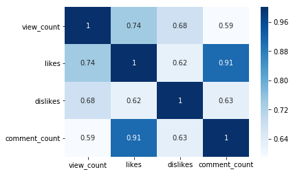

```python
# Vlsualize the correlation between view_count, likes,dislikes, and comment_count
correlation=data[['view_count','likes','dislikes','comment_count']].corr()
sns.heatmap(correlation,cmap='Blues',annot=True)
```

By simply plot the heatmap we can see the correlations between view_count, likes, dislikes, and comment_count. So it seems that increase in like contribute the most in increase comment_count. View_count and comment_count don't have that strong correlation.

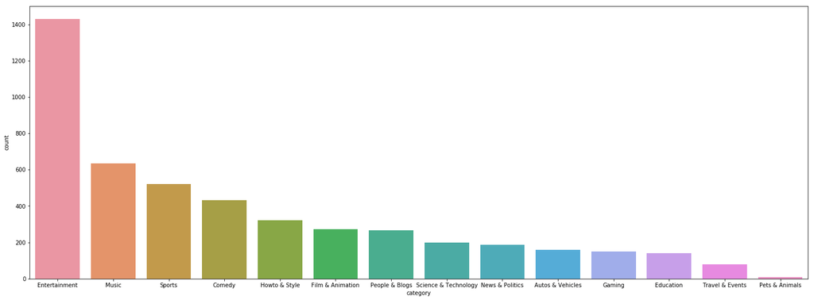

```python
# Plot the number of video by category
plt.figure(figsize = (25,9))
sns.countplot(data['category'],order = data['category'].value_counts().index)
```

Entertainment has the most videos showing up in the trending video, which is more than twice the second. This only can present that the majority group of videos are belong to entertainment, and the competition under entertainment channels may be very fierce. Then we would like to see the distribution of 'view_count', 'likes', 'dislikes', 'comment_count' by different categories.

```python
# Plot the distribution of 'view_count','likes','dislikes','comment_count'
view_count=np.log(data['view_count']+1 )
likes=np.log(data['likes']+1)
dislikes=np.log(data['dislikes']+1)
comment=np.log(data['comment_count']+1)
data_count=pd.concat([view_count,likes,dislikes,comment], axis=1)
data_count.index=data['category']
data_count=data_count[(data_count != 0)]
```

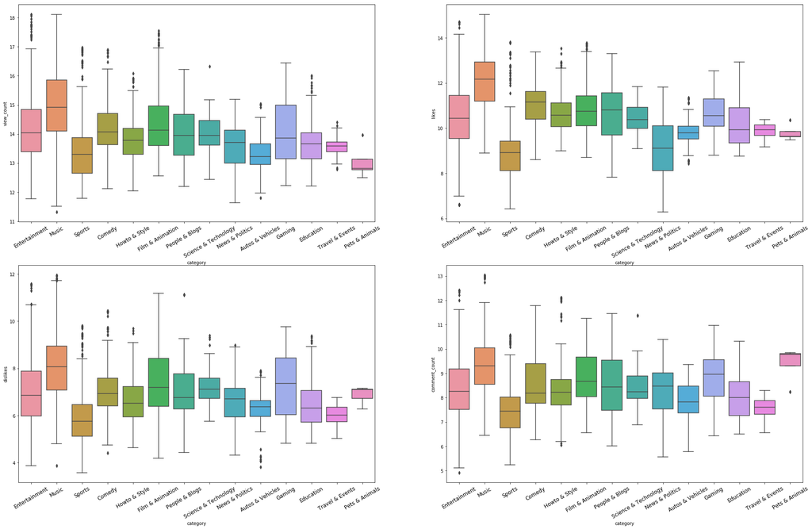

```python
plt.figure(figsize=(32,20))
plt.subplot(2,2,1)
sns.boxplot(data_count.index,'view_count', data=data_count,order = data['category'].value_counts().index)
plt.xticks(rotation=30,fontsize=12)
plt.subplot(2,2,2)
sns.boxplot(data_count.index,'likes', data=data_count,order = data['category'].value_counts().index)
plt.xticks(rotation=30,fontsize=12)
plt.subplot(2,2,3)
sns.boxplot(data_count.index,'dislikes', data=data_count,order = data['category'].value_counts().index)
plt.xticks(rotation=30,fontsize=12)
plt.subplot(2,2,4)
sns.boxplot(data_count.index,'comment_count', data=data_count,order = data['category'].value_counts().index)
plt.xticks(rotation=30,fontsize=12)
```

```python
general_view=pd.DataFrame(data[['view_count','likes','dislikes','comment_count']].groupby(data['category']).mean())
```

[output not shown]

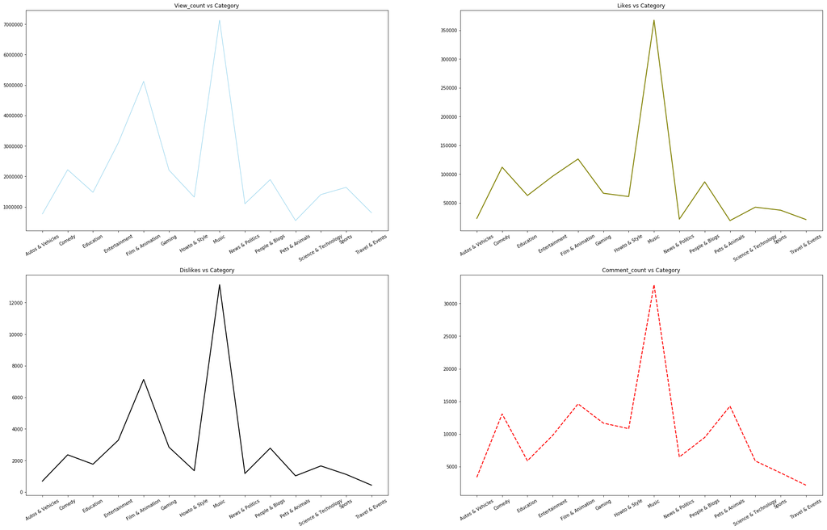

```python
# The average of four numeric attributes
plt.figure(figsize=(32,20))
plt.subplot(2,2,1)
plt.plot( general_view.index,'view_count' , data=general_view, color='skyblue', linewidth=1)
plt.title('View_count vs Category')
plt.xticks(rotation=30)
plt.subplot(2,2,2)
plt.plot( general_view.index, 'likes', data=general_view, color='olive', linewidth=2)
plt.title('Likes vs Category')
plt.xticks(rotation=30)
plt.subplot(2,2,3)
plt.plot( general_view.index, 'dislikes', data=general_view, color='black', linewidth=2)
plt.title('Dislikes vs Category')
plt.xticks(rotation=30)
plt.subplot(2,2,4)
plt.plot( general_view.index, 'comment_count', data=general_view, color='red', linewidth=2, linestyle='dashed')
plt.title('Comment_count vs Category')
plt.xticks(rotation=30)
```

By looking at the distribution of each attribute, we developed some insights: some categories have obviously high variance, such as music, entertainments, film&Animation, etc. This present the variety of videos in these categories, which polarization is very serious. Oppositely, some categories have very condensed distribution, like travel, Pets & Animals, auto &vehicles. This may because these categories have smaller but more stable audience Sports got in the top three show up frequency on the last graph, but all four distributions are lower than others. Pet also have the lowest view and number of video, but it shows more interactive between the audiences. Comparing to the count view by category, which Entertainment has the highest value, Music becomes the top category on all four attributes based on the distributions, so this show that Entertainment may not be the most popular category, only because it has the largest video base so it can have so many videos go up on trending, but music gets the most attention from people. Since music is a very personal thing, so it shows a high ratio between likes and dislikes.

```python
#the distribution of days that videos take to become popular
data['publish_date'] = data['publishedAt'].dt.date
data['publish_time'] = data['publishedAt'].dt.time
data['interval'] = (data['trending_date'].dt.date-data['publish_date']).astype('timedelta64[D]')
#Overview of distribution of interval
data.interval.describe()
```

```
count    4800.000000
mean        5.506042
std         3.371053
min         0.000000
25%         3.000000
50%         5.000000
75%         8.000000
max        15.000000
Name: interval, dtype: float64
```

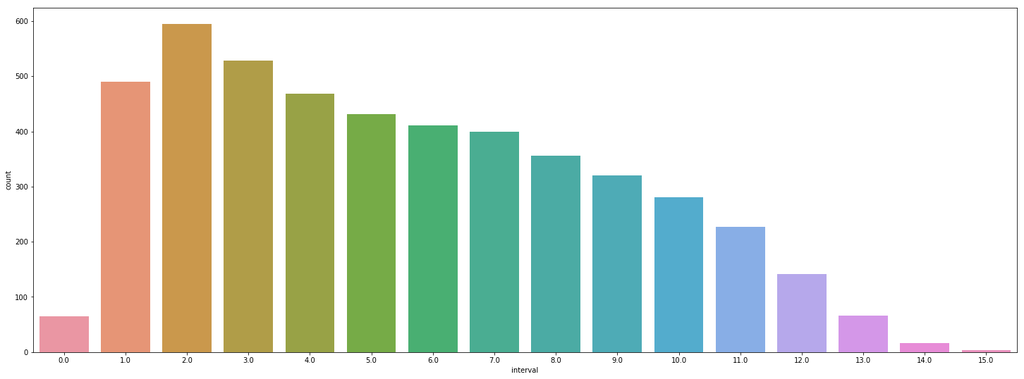

```python
#Histgram of distribution of interval
plt.figure(figsize = (25,9))
sns.countplot(data['interval'])
```

The distribution of intervals between video's publishing time and trending time shows that frequncy of interval incease to more than 500 when interval is 2days, and then decrease. We also found that if a video is older than half a month, generally, it can not appear on trending board.

```python
##Top videoes whoes view_count/likes grow fatest among categories

#calculate growth rate for each video
data['growth_rate_view'] = data['view_count']/(data['interval']+1)
data['growth_rate_like'] = data['likes']/(data['interval']+1)
data['growth_rate_dislike'] = data['dislikes']/(data['interval']+1)
data['growth_rate_comment'] = data['comment_count']/(data['interval']+1)

df = data.set_index(keys='title').groupby(by=['category'])['channelTitle','growth_rate_view'].apply(
    lambda g: g.nlargest(10,'growth_rate_view'))
df.head(40)
```

| category | title | channelTitle | growth_rate_view |
| --- | --- | --- | --- |
| Autos & Vehicles | Model Y Unveil | Tesla | 7.108547e+05 |
|  | Model Y Unveil | Tesla | 6.863875e+05 |
|  | Model Y Unveil | Tesla | 6.026014e+05 |
|  | Here's Why the 2019 BMW X7 Is the Best Big Luxury SUV | Doug DeMuro | 5.409695e+05 |
|  | Model Y Unveil | Tesla | 5.373847e+05 |
|  | The Saleen S7 Is the Craziest Supercar Nobody Knows About | Doug DeMuro | 5.163707e+05 |
|  | The Saleen S7 Is the Craziest Supercar Nobody Knows About | Doug DeMuro | 4.721725e+05 |
|  | Model Y Unveil | Tesla | 4.669276e+05 |
|  | Model Y Unveil | Tesla | 4.177008e+05 |
|  | The Saleen S7 Is the Craziest Supercar Nobody Knows About | Doug DeMuro | 4.139040e+05 |
| Comedy | Maisie Williams Accidentally Drops a Major Spoiler in Game of Thrones' Final Season | The Tonight Show Starring Jimmy Fallon | 3.014781e+06 |
|  | Maisie Williams Accidentally Drops a Major Spoiler in Game of Thrones' Final Season | The Tonight Show Starring Jimmy Fallon | 2.615266e+06 |
|  | The Spiders and the Bees | TheOdd1sOut | 2.510830e+06 |
|  | The Spiders and the Bees | TheOdd1sOut | 2.428940e+06 |
|  | The Spiders and the Bees | TheOdd1sOut | 2.378457e+06 |
|  | The Spiders and the Bees | TheOdd1sOut | 2.252175e+06 |
|  | The Spiders and the Bees | TheOdd1sOut | 2.215552e+06 |
|  | The Spiders and the Bees | TheOdd1sOut | 2.157888e+06 |
|  | The Spiders and the Bees | TheOdd1sOut | 2.006741e+06 |
|  | A Tour Of My Plants | JennaMarbles | 1.877655e+06 |
| Education | What If We Detonated All Nuclear Bombs at Once? | Kurzgesagt – In a Nutshell | 1.755290e+06 |
|  | What If We Detonated All Nuclear Bombs at Once? | Kurzgesagt – In a Nutshell | 1.649115e+06 |
|  | What If We Detonated All Nuclear Bombs at Once? | Kurzgesagt – In a Nutshell | 1.474106e+06 |
|  | What If We Detonated All Nuclear Bombs at Once? | Kurzgesagt – In a Nutshell | 1.264566e+06 |
|  | The Origin of Consciousness – How Unaware Things Became Aware | Kurzgesagt – In a Nutshell | 1.178408e+06 |
|  | The Origin of Consciousness – How Unaware Things Became Aware | Kurzgesagt – In a Nutshell | 9.911678e+05 |
|  | The Origin of Consciousness – How Unaware Things Became Aware | Kurzgesagt – In a Nutshell | 8.159958e+05 |
|  | 9 PEOPLE YOU DON'T WANT TO MESS WITH | #Mind Warehouse | 8.003252e+05 |
|  | 9 PEOPLE YOU DON'T WANT TO MESS WITH | #Mind Warehouse | 7.784711e+05 |
|  | 9 PEOPLE YOU DON'T WANT TO MESS WITH | #Mind Warehouse | 7.491722e+05 |
| Entertainment | Marvel Studios' Avengers: Endgame - Official Trailer | Marvel Entertainment | 2.232652e+07 |
|  | EXPERIMENT: LAVA vs FISH | SkyBek | 2.203405e+07 |
|  | Marvel Studios' Avengers: Endgame - Official Trailer | Marvel Entertainment | 2.012123e+07 |
|  | Marvel Studios' Avengers: Endgame - Official Trailer | Marvel Entertainment | 1.878956e+07 |
|  | EXPERIMENT: LAVA vs FISH | SkyBek | 1.586332e+07 |
|  | Marvel Studios' Avengers: Endgame - Official Trailer | Marvel Entertainment | 1.572887e+07 |
|  | EXPERIMENT: LAVA vs FISH | SkyBek | 1.226287e+07 |
|  | Marvel Studios' Avengers: Endgame - Official Trailer | Marvel Entertainment | 1.169769e+07 |
|  | Marvel Studios' Avengers: Endgame - Official Trailer | Marvel Entertainment | 1.040558e+07 |
|  | Kalank \| Official Teaser \| Varun \| Aditya Roy \| Sanjay \| Alia \| Sonakshi \| Madhuri \| Abhishek Varman | FoxStarHindi | 1.033005e+07 |

We found the top videos with highest growth rates of views were published by certain youtube channels, meaning that these channels can attract lots of people in a short time. So, advertisers and investors can find valuable channels to cooperate.

```python
Channel=pd.DataFrame(data['channelTitle'].groupby(by=[data['channelTitle'],data['category']]).count())
Channel.columns=['count']
Top_channel=Channel.nlargest(100,['count'])
Top_channel
```

| channelTitle | category | count |
| --- | --- | --- |
| American Idol | Entertainment | 24 |
| Billie Eilish | Music | 24 |
| Binging with Babish | Entertainment | 24 |
| BuzzFeedVideo | People & Blogs | 24 |
| CinemaSins | Film & Animation | 24 |
| Cleetus McFarland | Film & Animation | 24 |
| Doug DeMuro | Autos & Vehicles | 24 |
| FBE | Entertainment | 24 |
| Good Mythical MORE | Entertainment | 24 |
| Good Mythical Morning | Entertainment | 24 |
| Gordon Ramsay | Entertainment | 24 |
| James Charles | Entertainment | 24 |
| JennaMarbles | Comedy | 24 |
| Linus Tech Tips | Science & Technology | 24 |
| Marques Brownlee | Science & Technology | 24 |
| Netflix | Entertainment | 24 |
| Philip DeFranco | News & Politics | 24 |
| REACT | Entertainment | 24 |
| Rosanna Pansino | Howto & Style | 24 |
| Skip and Shannon: UNDISPUTED | Sports | 24 |
| Strictly Dumpling | Travel & Events | 24 |
| Tati | Howto & Style | 24 |
| The King of Random | Education | 24 |
| The Slow Mo Guys | Entertainment | 24 |
| The Voice | Entertainment | 24 |
| Unbox Therapy | Science & Technology | 24 |
| goonzquad | Howto & Style | 24 |
| DOPE or NOPE | Comedy | 23 |
| Ladylike | People & Blogs | 23 |
| NFL | Sports | 23 |
| ... | ... | ... |
| VICE | Entertainment | 18 |
| ibighit | Music | 18 |
| First We Feast | Entertainment | 17 |
| GQ | Entertainment | 17 |
| LaurDIY | Howto & Style | 17 |
| SSSniperWolf | Entertainment | 17 |
| Safiya Nygaard | People & Blogs | 17 |
| Saturday Night Live | Entertainment | 17 |
| The Tonight Show Starring Jimmy Fallon | Comedy | 17 |
| The Verge | Science & Technology | 17 |
| jypentertainment | Music | 17 |
| BillieEilishVEVO | Music | 16 |
| Complex | Entertainment | 16 |
| Domics | Comedy | 16 |
| Fortnite | Gaming | 16 |
| Jimmy Kimmel Live | Entertainment | 16 |
| Kristopher London | Sports | 16 |
| Lil Skies | Music | 16 |
| Lionsgate Movies | Film & Animation | 16 |
| NBC World of Dance | Entertainment | 16 |
| Robby | People & Blogs | 16 |
| Tasty | Howto & Style | 16 |
| B/R Football | Sports | 15 |
| Channel Awesome | Entertainment | 15 |
| DailyDrivenExotics | Autos & Vehicles | 15 |
| Epicurious | Entertainment | 15 |
| Jeopardy! | Entertainment | 15 |
| Mnet K-POP | Entertainment | 15 |
| Smosh | Comedy | 15 |
| THE PRINCE FAMILY | People & Blogs | 15 |

100 rows × 1 columns

We would like to know which channels are the most productive, and what categories they belong to. so we find the top 100 channels that have the most videos pop up on trending. It seems that these channels with 24videos get on trending every day, so we will explore more on these channels.

# 3. Sentiment Analysis

The goal of performing sentiment analysis here is to identify the keywords associated with a video to be able to categorize them. For example, a video with the title “BBC Channel” will belong to the News & Politics category and so on. Similarly, we also perform word cloud on description and tags of the video to get a visual representation of what Youtubers are specify on their video.  
We intend to obtain a quick overall sense for what elements a channel performed to audience. We could recommend a detailed trending YouTube Video image description to help investors and advertisers to identify those potential trending videos.

```python
category_list = data['category'].unique()
category_list
```

```
array(['Comedy', 'Music', 'Sports', 'Film & Animation', 'Entertainment',
       'Autos & Vehicles', 'Howto & Style', 'Science & Technology',
       'Gaming', 'Travel & Events', 'News & Politics', 'People & Blogs',
       'Education', 'Pets & Animals'], dtype=object)
```

```python
#Collect all the related stopwords.
en_stopwords = list(stopwords.words('english'))
polarities = list()
MAX_N=10000

for i in category_list:
    tags_word = data[data['category']==i]['tags'].str.lower().str.cat(sep=' ')

# removes punctuation,numbers and returns list of words
    tags_word = re.sub('[^A-Za-z]+', ' ', tags_word)
    word_tokens = word_tokenize(tags_word)
    filtered_sentence = [w for w in word_tokens if not w in en_stopwords]
    without_single_chr = [word for word in filtered_sentence if len(word) > 2]

# Remove numbers
    cleaned_data_title = [word for word in without_single_chr if not word.isdigit()]

# Calculate frequency distribution
    word_dist = nltk.FreqDist(cleaned_data_title)
    hnhk = pd.DataFrame(word_dist.most_common(MAX_N),
                    columns=['Word', 'Frequency'])

    compound = .0
    for word in hnhk['Word'].head(MAX_N):
        compound += SentimentIntensityAnalyzer().polarity_scores(word)['compound']

    polarities.append(compound)
```

```
Text(0.5,1,'\nPolarity of Different Categories videos\n')
```

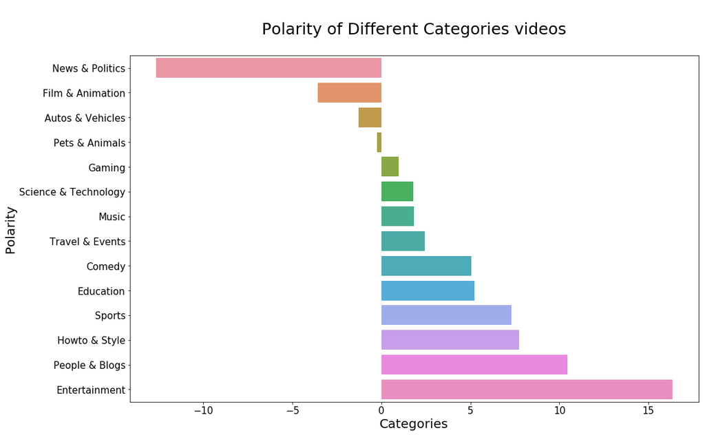

```python
category_list = pd.DataFrame(category_list)
polarities = pd.DataFrame(polarities)
tags_sentiment = pd.concat([category_list,polarities],axis=1)
tags_sentiment.columns = ['category','polarity']
tags_sentiment=tags_sentiment.sort_values('polarity').reset_index()

plt.figure(figsize=(16,10))
ax = sns.barplot(x=tags_sentiment['polarity'],y=tags_sentiment['category'], data=tags_sentiment)

plt.xlabel("Categories",fontsize=20)
plt.ylabel("Polarity",fontsize=20)
plt.yticks(fontsize=15)
plt.xticks(fontsize=15)
plt.title("\nPolarity of Different Categories videos\n", fontsize=25)
```

While Entertainment, music, and sports videos have positive polarity. The categories of videos have a specific type of audiences. We recommend that the audiences watching Positive polarity videos if the audiences have a Harmonious atmosphere party because the relatively higher positive polarity videos are usually family-friendly and those videos will also have a higher positive comment.

```python
def word_cloud(data):
    plt.figure(figsize = (20,15),facecolor = None)
    cloud = WordCloud(background_color = 'black', colormap="tab20b_r",max_words=2000, max_font_size=40, random_state=42)
    cloud.generate(' '.join(data))
    plt.imshow(cloud)
    plt.axis('off')
    plt.title("\nWord cloud for " + 'data' + "\n", fontsize=45)
```

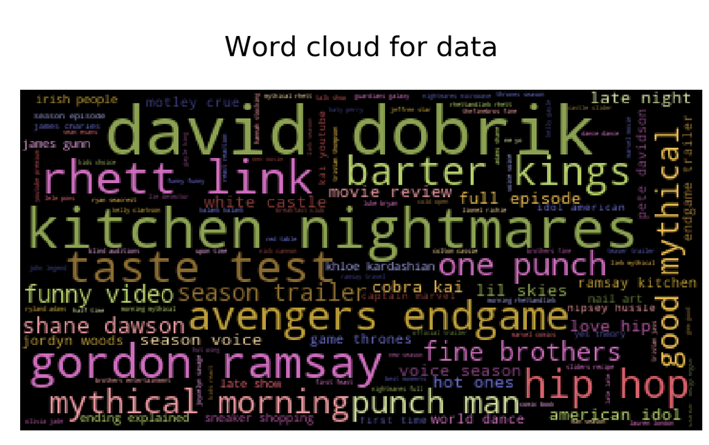

```python
tags_word = data[data['category']=='Entertainment']['tags'].str.lower().str.cat(sep=' ')

word_tokens = word_tokenize(tags_word)
filtered_sentence = [w for w in word_tokens if not w in en_stopwords]
without_single_chr = [word for word in filtered_sentence if len(word) > 2]
cleaned_data_title = [word for word in without_single_chr if not word.isdigit()]

word_cloud(cleaned_data_title)
```

# Project Progress Updated

The next stage we will analysis based on these statistic results we found and dig into details. We will calculate the average growth rates by dividing counted values to time intervals, and weight the popularity rate, engagement rate to get a final ranking results. We will keep looking down into channels by categories since different category represents a different group of audience, and we will analyse the behaviors/phenomenon behind these statistics, like the changing rate of the like/dislike ratio. We found that there are many trending videos managed to get a large number of views counts, but they have very few likes, so we could analyze the reason for this abnormal situation. In addition, for the overall report quality, we will revise our graphs for better visualization to make a comprehensive performance evaluation further. For the sentiment analysis part, we will revise the word cloud algorithm to have more valuable and informational tags appear, and we have planned for additional analysis for description sentiment.